# Reading the Capability Map

A Handbook for the Capability Gap Radar — Need vs. Achievement, and its Model Implications for Industrial Strategy

Author

Net Zero Industrial Policy Lab (NZIPL) · Johns Hopkins SAIS

Published

July 8, 2026

> **What this is.** A working handbook for reading the model-driven **Capability Gap Radar** of the *Atlas of the Clean Industrial Base* — and its finer companion, the **PC Scatter** — and turning them into industrial-strategy calls. It explains the one idea both panels encode (a *gap* between what a technology **needs** and what a country **has achieved**), the seven-cell grid that names every gap, and a worked example for each cell drawn from live model output (a recent three-year window, six focal countries). The method behind the two axes is documented in `capability_radar_methodology.qmd`; this note is the reader’s guide to *using* them.

# 1 How to use this handbook

The framework is deliberately **coarse**. It classifies *clusters* of capability, not individual products. As the underlying working paper puts it: precision beyond the cluster level “would be applying a false level of precision to the model.” The handbook is a guide to reasoning, not a recipe.

# 2 The two questions behind every panel

Both panels answer two questions at once and plot one against the other.

**What does the technology *need*? — the winners’-recipe target.** The competitiveness model (a Random Forest predicting whether a country reaches `RCA > 1` in a clean technology) tells us which capabilities carry the predictive signal. But we do not read its importances naively: we take the model’s **signed** SHAP contributions and average them **over only the country-years where a producer is actually competitive** — the winners. Summing those to five capability clusters — **Chemicals, Electronics, Industrial Materials, Machinery, Metals** — gives a **target share** $t_c$ (% of the winners’ recipe) for each cluster. High share = a capability competitive producers genuinely lean on. Crucially this is *magnitude-weighted*, not a count of HS codes, and *direction-checked* (see `target_profile.qmd`), so it names the cluster that matters, not merely the one with the most products.

**What has the country *achieved*? — the achievement fraction.** For each cluster we take the country’s *own* recent competitive-class signed SHAP and divide it by that cluster’s target weight. The result, the **achievement fraction** $a_c$, is *what the country has ÷ what the technology needs*: $a_c \geq 1$ means the country sits at the winners’ frontier, $a_c \to 0$ means the capability is essentially absent. Because the numerator is the country’s own signal, achievement carries all the country-specific information — the frontier is shared, the achievement is unique.

| Panel | Need | Achievement / Have | Granularity |
| --- | --- | --- | --- |
| **Capability Radar** | dashed frontier, 5 axes (winners’ recipe) | green fill, 5 axes (achievement fraction) | **Category** (5 clusters) |
| **PC Scatter** | x-axis (product SHAP importance) | y-axis product RCA (bubble = trade value) | **Product** (HS6) |

The radar and the scatter are **the same comparison at two zoom levels**. The radar reads each cluster’s achievement against its need; the scatter shows the individual products inside a cluster. This distinction is not cosmetic — it is the single most common source of misreading (§4.1).

# 3 The gap framework: a seven-cell grid

Crossing three **need** levels with three **achievement** levels yields a 3×3 grid that collapses to **seven policy-relevant cells**.

**Need level (what the technology requires — winners’-recipe target share)**

| Level | Threshold | Meaning |
| --- | --- | --- |
| Core | $t_c \geq 30\%$ | A cluster competitive producers genuinely lean on — usually one or two per tech, running 30–76% |
| Supporting | $10\% \leq t_c < 30\%$ | A real but secondary requirement |
| Peripheral | $t_c < 10\%$ | The technology barely draws on this cluster |

**Achievement level (what the country holds, relative to that need)**

| Level | Threshold | Meaning |
| --- | --- | --- |
| At frontier | $a_c \geq 1.0$ | Already at the winners’ level ($\gg 1$ = surplus) |
| Partial | $0.5 \leq a_c < 1.0$ | Meaningfully building, still below the frontier |
| Behind | $a_c < 0.5$ | Little or none of the required capability yet |

**The grid**

|  | **At frontier** $a\geq1$ | **Partial** $0.5\leq a<1$ | **Behind** $a<0.5$ |
| --- | --- | --- | --- |
| **Core need** $\geq30\%$ | 🟢 **Leverage** | 🟠 **Build-up** | 🔴 **Critical gap** |
| **Supporting** 10–30% | 🟡 **Mature strength** | 🟠 **Build-up** | 🟥 **Gap** |
| **Peripheral** $<10\%$ | 🔵 **Bonus strength** | ⚪ **Not a priority** | ⚪ **Not a priority** |

The diagonal logic is the whole point: the **top-left** is where a country’s achievement meets the technology’s core need (act here first), and the **top-right** is where the technology’s most important need is unmet (the hardest, most strategic problem).

# 4 The seven cells, with worked examples

Each cell below pairs the reading rule with a real case from model output. The recurring cases — **India · Solar**, **Brazil · Biofuel**, **Mexico · Heat Pumps** — reappear because a single country×technology typically spans several cells across its five clusters. That is normal and is exactly how the map is meant to be read.

## 4.1 A note before the cells: radar vs. scatter

Brazil · Biofuel — capability radar (category level)

| Cluster | Need % | Achievement | Classification |
| --- | --- | --- | --- |
| Chemicals | 40.7 | 53% | Build-up |
| Machinery | 30.4 | 70% | Build-up |
| Industrial Materials | 26.6 | 69% | Build-up |
| Metals | 2.3 | 0% | Not a priority |
| Electronics | 0.0 | 0% | Not a priority |

On the **radar**, Brazil · Biofuel shows no Leverage cell — its core and supporting clusters (Chemicals, Machinery, Industrial Materials) all sit in **Build-up**, meaningfully built but not yet at the frontier. Yet on the **PC scatter**, Brazil holds clear **leverage products**: sugarcane-derived ethanol and processing inputs where its product-level RCA is far above 1 and the model weights the product heavily. Both readings are correct. The category average dilutes a handful of star products; the scatter resolves them. **Rule: use the radar to set the strategic frame, the scatter to find the specific products to anchor.**

## 4.2 🟢 Leverage — *achievement meets core need*

**Reading rule:** Core need ($\geq30\%$) **and** achievement $\geq 1$. The country already sits at the frontier in the capability the technology most demands.

**Policy orientation:** Anchor FDI and supply-chain strategy here. This is the nucleus to build outward from — the country competes where it counts. A large surplus ($a_c \gg 1$) is spare capacity to redeploy.

**Worked case — Mexico · Heat Pumps.**

Mexico · Heat Pumps — capability radar (category level)

| Cluster | Need % | Achievement | Classification |
| --- | --- | --- | --- |
| Machinery | 75.9 | 138% | Leverage |
| Metals | 12.9 | 94% | Build-up |
| Electronics | 7.3 | 164% | Bonus strength |
| Industrial Materials | 2.2 | 216% | Bonus strength |
| Chemicals | 1.7 | 118% | Bonus strength |

Machinery is the overwhelming core need of heat pumps (the winners’ recipe is machinery-dominated), and Mexico sits at or beyond that frontier — the textbook leverage position: the country is strong exactly where the technology is decided.

## 4.3 🟠 Build-up — *close enough to matter*

**Reading rule:** Core or Supporting need **and** Partial achievement ($0.5 \leq a < 1$). The country is just below the frontier in a capability that matters.

**Policy orientation:** Highest expected return on targeted investment. A modest push to reach $a_c = 1$ converts a near-miss into a genuine strength. Expect an import surge in the relevant capital goods before the export signal follows.

**Worked case — Brazil · Biofuel (above).** All three of Brazil’s non-trivial biofuel clusters sit in Build-up — Chemicals, Machinery and Industrial Materials each at roughly half to two-thirds of the frontier. This is a country one coordinated push from competitiveness across the capabilities biofuel most rewards, consistent with its established ethanol complex.

## 4.4 🔴 Critical gap — *the top driver is missing*

**Reading rule:** Core need ($\geq30\%$) **and** Behind ($a < 0.5$). The model’s single most important capability is absent.

**Policy orientation:** The hardest problem. Requires upstream industrial policy — sector-building, not just incentives. Cannot be closed by demand subsidies alone.

**Worked case — India · Solar.**

India · Solar — capability radar (category level)

| Cluster | Need % | Achievement | Classification |
| --- | --- | --- | --- |
| Electronics | 61.6 | 17% | Critical gap |
| Chemicals | 23.3 | 81% | Build-up |
| Metals | 8.4 | 101% | Bonus strength |
| Machinery | 6.1 | 259% | Bonus strength |
| Industrial Materials | 0.5 | 4% | Not a priority |

## 4.5 🟡 Mature strength — *real but not decisive*

**Reading rule:** Supporting need (10–30%) **and** achievement $\geq 1$. A genuine capability at the frontier, in a cluster of secondary importance.

**Policy orientation:** Maintain and deepen. Useful, but not enough on its own to carry a technology strategy.

**Worked case — Japan · Magnets.** The Machinery cluster (need 21%, achievement 211%) is a maintained specialisation that supports, but does not by itself decide, competitiveness in this technology.

## 4.6 🟥 Gap — *a secondary driver missing*

**Reading rule:** Supporting need (10–30%) **and** Behind ($a < 0.5$). An important-but-not-critical capability is absent.

**Policy orientation:** Worth addressing, but not a show-stopper alone. Sequence it after the critical gaps.

**Worked case — India · Biofuel.** The Industrial Materials cluster is a supporting need (27%) the country has barely built (achievement 0%) — a real but second-order weakness to address once the core gaps are underway.

## 4.7 🔵 Bonus strength — *strength the tech doesn’t reward*

**Reading rule:** Peripheral need ($<10\%$) **and** achievement $\geq 1$. A frontier (often surplus) capability in a cluster this technology weights lightly.

**Policy orientation:** Do **not** anchor tech-specific strategy here — but flag it: this strength may be decisive for a *different* technology. A cross-technology asset.

**Worked case — India · Geothermal.** A frontier Industrial Materials position (achievement 265%) that the Geothermal recipe weights only 1% — real capability, but better leveraged for a technology that prizes it.

## 4.8 ⚪ Not a priority — *neither side cares*

**Reading rule:** Peripheral need **and** Partial/Behind achievement. Neither the technology nor the country emphasises this cluster.

**Policy orientation:** Low-salience. Note and move on — strategy capacity is better spent on the actionable cells above.

**Worked case — India · Solar · Industrial Materials.** Trivial model need (≈1% of the winners’ recipe) and near-zero Indian achievement: correctly ignored in a solar strategy.

# 5 The worked cases, as radars

The five cases above, drawn as capability gap radars. On each, the **dashed pentagon** is the winners’ frontier (100% of the need) and the **green fill** is the country’s achievement fraction per cluster; each axis is labelled with its achievement (values above 100% are surpluses, drawn clipped to the ring). The **axis-label colour is the seven-cell class** (key in the sixth panel) — this is what carries the *need* magnitude, so a low green vertex reads very differently under a red **Critical gap** label than under a grey **Not a priority** one. Reading the shape together with the colour: a green vertex reaching the ring under a green/red label sits on a cluster the technology needs; one collapsing toward the centre under a red label is the strategic gap.

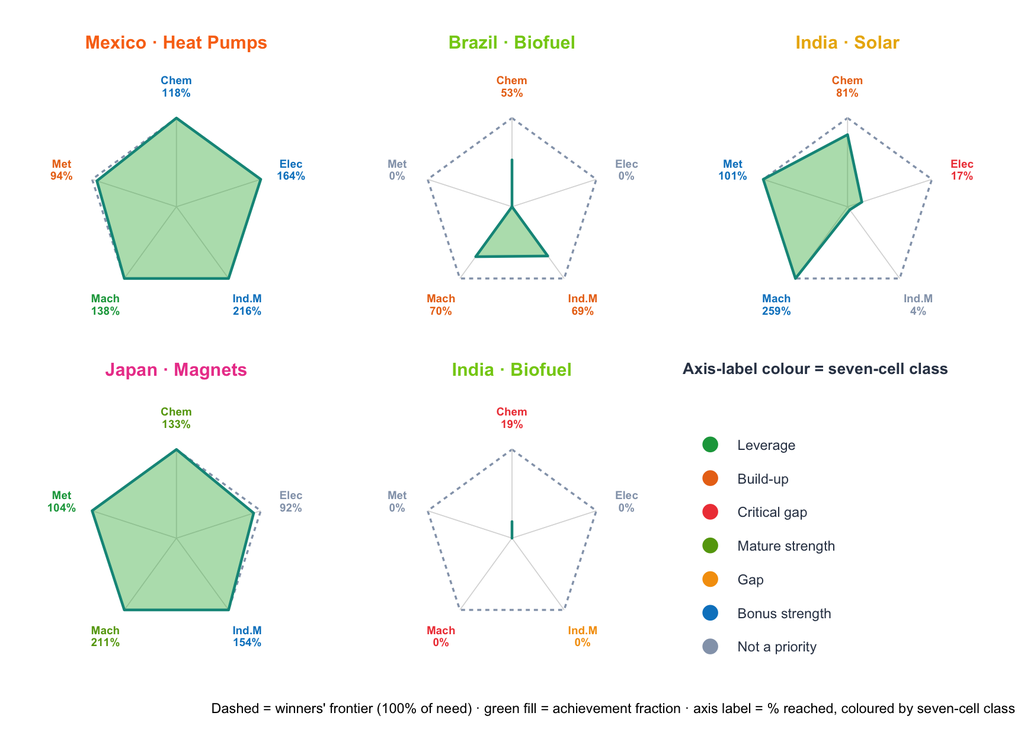

Reading the five together: **Mexico · Heat Pumps** fills its core Machinery axis to the ring (green *Leverage* label); **Brazil · Biofuel** sits part-way out on its three needs (orange *Build-up* labels across the board); **India · Solar** is full on Machinery/Metals — but those wear blue *Bonus strength* labels, while the near-empty Electronics axis wears the red *Critical gap* one; **Japan · Magnets** overshoots Machinery under a *Mature strength* label; and **India · Biofuel** shows the feedstock-processing shape thinned toward the centre, its Industrial Materials axis a *Gap*.

# 6 A full read: India · Solar, end to end

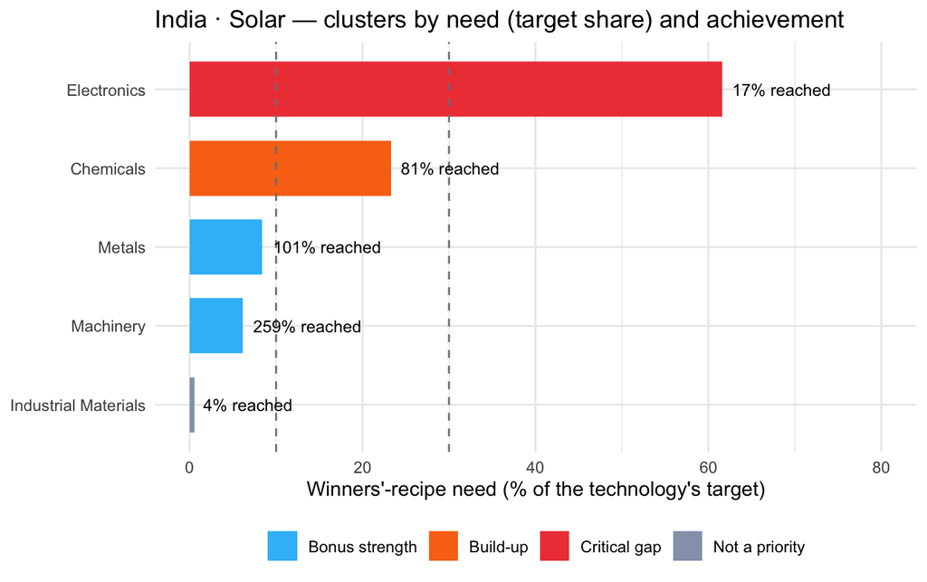

Read top to bottom by need: **Electronics** is the top driver and a **Critical gap** (the strategic priority — India reaches only ≈17% of the frontier). **Chemicals** is a supporting need India has largely met — a **Build-up** to finish. **Metals** and **Machinery** are at or beyond the frontier but *peripheral* for solar — **Bonus strength**, real capability that matters more for other technologies (magnets, wind) than for solar. **Industrial Materials** is **Not a priority**. One panel, a complete sequencing of where to act and in what order — and, notably, it points Indian solar policy at **electronics** sector-building, not the chemicals layer a product-count reading would have flagged.

# 7 What the map does not say

- **Clusters, not products.** A core-need cluster signals *what kind* of capability matters, not a list of HS6 codes to build. Use the scatter to descend to products, but treat product specifics as illustration, not prescription.
- **Radar dilutes; scatter resolves.** A Build-up cluster can hide a leverage product (and vice versa). Always cross-check the two panels (§4.1).
- **Macro features are excluded.** The model also learns from FDI, trade openness, GDP and other country covariates; the need is built over the five *traded-capability* clusters only. A country can have a clean radar yet face non-trade barriers.
- **Achievement is a recent, revealed signal.** The achievement fraction reads the country’s own competitive-class contribution over a recent three-year window — it reflects capability the country has *revealed*, not nascent capacity. Pair with the trade-timeline and firm-activity panels for momentum.
- **The frontier is shared, not local.** The need is the winners’ recipe, identical for every country by design; a country very unlike the typical winner still gets measured against the same frontier. That is the intended reading of “a standard profile countries evolve toward,” but it means the map answers *what to build toward*, not *the only path there*.
- **Thresholds are conventions.** The 30% / 10% and 1.0 / 0.5 lines are defensible but not magic. Cases near a line should be read as “between cells,” not snapped to one.

## 8 One-page cheat sheet

| Cell | Need (target share) | Achievement | Do |
| --- | --- | --- | --- |
| **Leverage** | Core | At frontier | Anchor FDI; build outward |
| **Build-up** | Core/Supporting | Partial | Invest — highest return; reach the frontier |
| **Critical gap** | Core | Behind | Sector-build upstream; hardest problem |
| **Mature strength** | Supporting | At frontier | Maintain and deepen |
| **Gap** | Supporting | Behind | Address after critical gaps |
| **Bonus strength** | Peripheral | At frontier | Don’t anchor here; asset for another tech |
| **Not a priority** | Peripheral | Partial/Behind | Note and move on |

*Radar = category zoom (set the frame). Scatter = product zoom (find the anchor). Need = winners’-recipe target share; achievement = country’s signed SHAP ÷ that need, recent three-year window.*